# SI 618 Homework #4

## Taylor Swift songs

Last updated 2023-10-04

The dataset for this assignment is from https://www.kaggle.com/datasets/jarredpriester/taylor-swift-spotify-dataset/data.

**NOTE**: Use the dataset from Canvas rather than the dataset from Kaggle, which is updated frequently and may change while you are completing this assignment.

This dataset consist of data from Spotify's API on all albums listed on Spotify for Taylor Swift. I set up the dataset to update monthly so that if any albums get added it will get added to the dataset too. At first it may look like there are song duplicates but I checked and all song IDs are unique.

The columns in this dataset are:

name - the name of the song

album - the name of the album

release_date - the day month and year the album was released

track number - the order the song appears on the album

id - the Spotify id for the song

uri - the Spotify uri for the song

acousticness - A confidence measure from 0.0 to 1.0 of whether the track is acoustic. 1.0 represents high confidence the track is acoustic.

danceability - Danceability describes how suitable a track is for dancing based on a combination of musical elements including tempo, rhythm stability, beat strength, and overall regularity. A value of 0.0 is least danceable and 1.0 is most danceable.

energy - Energy is a measure from 0.0 to 1.0 and represents a perceptual measure of intensity and activity. Typically, energetic tracks feel fast, loud, and noisy. For example, death metal has high energy, while a Bach prelude scores low on the scale. Perceptual features contributing to this attribute include dynamic range, perceived loudness, timbre, onset rate, and general entropy.

instrumentalness - Predicts whether a track contains no vocals. "Ooh" and "aah" sounds are treated as instrumental in this context. Rap or spoken word tracks are clearly "vocal". The closer the instrumentalness value is to 1.0, the greater likelihood the track contains no vocal content. Values above 0.5 are intended to represent instrumental tracks, but confidence is higher as the value approaches 1.0.

liveness - Detects the presence of an audience in the recording. Higher liveness values represent an increased probability that the track was performed live. A value above 0.8 provides strong likelihood that the track is live.

loudness - The overall loudness of a track in decibels (dB). Loudness values are averaged across the entire track and are useful for comparing relative loudness of tracks. Loudness is the quality of a sound that is the primary psychological correlate of physical strength (amplitude). Values typically range between -60 and 0 db.

speechiness - detects the presence of spoken words in a track. The more exclusively speech-like the recording (e.g. talk show, audio book, poetry), the closer to 1.0 the attribute value. Values above 0.66 describe tracks that are probably made entirely of spoken words. Values between 0.33 and 0.66 describe tracks that may contain both music and speech, either in sections or layered, including such cases as rap music. Values below 0.33 most likely represent music and other non-speech-like tracks.

tempo - The overall estimated tempo of a track in beats per minute (BPM). In musical terminology, tempo is the speed or pace of a given piece and derives directly from the average beat duration.

valence - A measure from 0.0 to 1.0 describing the musical positiveness conveyed by a track. Tracks with high valence sound more positive (e.g. happy, cheerful, euphoric), while tracks with low valence sound more negative (e.g. sad, depressed, angry).

popularity - the popularity of the song from 0 to 100

duration_ms - The duration of the track in milliseconds.

We are going to refer to the tracks' properties of danceability, energy, instrumentalness, liveness, loudness, speechiness, tempo, and valence as "features" of the tracks.

Each of the questions is worth the same number of points, except for the final bonus question, which is worth up to an additional 2 points (out of 100). Points will be allocated according to the following rubric:

- 90-100%: Question is correctly and completely answered. Answer consists of well-written code that conforms to [PEP 8](https://www.python.org/dev/peps/pep-0008/) guidelines and is accompanied by a written interpretation in a Markdown block. Written interpretation does not contain spelling, grammar or stylistic errors (see [Strunk & White](https://drive.google.com/file/d/1L0P7xJwjUGBvyb49mL3dw1Bt7hzRTiTl/view?usp=sharing) for a detailed specifications). Minor problems, such as formatting, incorrect submissions, missing names, etc. will result in less than 100%.
- 75-85% : Answer is mostly complete and correct; two or fewer noticeable omissions or errors. Minor stylistic flaws, either in code or in written interpretation.
- 50-70%: Answer has significant omissions or errors; Noticeable departure from PEP-8 guildelines and/or moderate spelling, grammar, or style issues in written interpretations.
- 25-45%: Question is perfunctorily attempted. Substantial parts are missing or incorrect.
- 0 points: Question not attempted.

Be sure to include interpretations of your results for each question.

```python
import pandas as pd
import seaborn as sns
from statsmodels.graphics.mosaicplot import mosaic
from scipy.stats import chi2_contingency
import numpy as np
import matplotlib.pyplot as plt
import matplotlib.pyplot as plt
import seaborn as sns
from scipy import stats
from scipy.stats import ttest_ind
```

Q1: Show the distribution of the popularity of the songs. Then exclude the songs that are from karaoke albums (i.e., the album name contains "karaoke"). Show the distribution of the popularity of the songs. What is the difference between the two distributions?

```python
songs = pd.read_csv('./taylor_swift_spotify.csv', index_col=0)
songs.head()
```

|  | name | album | release_date | track_number | id | uri | acousticness | danceability | energy | instrumentalness | liveness | loudness | speechiness | tempo | valence | popularity | duration_ms |
| --- | --- | --- | --- | --- | --- | --- | --- | --- | --- | --- | --- | --- | --- | --- | --- | --- | --- |
| 0 | Lavender Haze | Midnights (3am Edition) | 2022-10-22 | 1 | 4g2c7NoTWAOSYDy44l9nub | spotify:track:4g2c7NoTWAOSYDy44l9nub | 0.2040 | 0.735 | 0.444 | 0.001200 | 0.1700 | -10.519 | 0.0684 | 97.038 | 0.0984 | 77 | 202395 |
| 1 | Maroon | Midnights (3am Edition) | 2022-10-22 | 2 | 199E1RRrVmVTQqBXih5qRC | spotify:track:199E1RRrVmVTQqBXih5qRC | 0.0593 | 0.658 | 0.378 | 0.000000 | 0.0976 | -8.300 | 0.0379 | 108.034 | 0.0382 | 76 | 218270 |
| 2 | Anti-Hero | Midnights (3am Edition) | 2022-10-22 | 3 | 02Zkkf2zMkwRGQjZ7T4p8f | spotify:track:02Zkkf2zMkwRGQjZ7T4p8f | 0.1330 | 0.638 | 0.634 | 0.000001 | 0.1520 | -6.582 | 0.0457 | 96.953 | 0.5190 | 77 | 200690 |
| 3 | Snow On The Beach (feat. Lana Del Rey) | Midnights (3am Edition) | 2022-10-22 | 4 | 6ADDIJxxqzM9LMpm78yzQG | spotify:track:6ADDIJxxqzM9LMpm78yzQG | 0.7350 | 0.659 | 0.323 | 0.003210 | 0.1160 | -13.425 | 0.0436 | 110.007 | 0.1540 | 74 | 256124 |
| 4 | You're On Your Own, Kid | Midnights (3am Edition) | 2022-10-22 | 5 | 7gVWKBcfIW93YxNBi3ApIE | spotify:track:7gVWKBcfIW93YxNBi3ApIE | 0.4160 | 0.694 | 0.380 | 0.000008 | 0.1260 | -10.307 | 0.0614 | 120.044 | 0.3760 | 76 | 194206 |

```python
songs_no_karaoke = songs[~songs.album.str.contains(r'[Kk]araoke')]
songs_no_karaoke.head()
```

|  | name | album | release_date | track_number | id | uri | acousticness | danceability | energy | instrumentalness | liveness | loudness | speechiness | tempo | valence | popularity | duration_ms |
| --- | --- | --- | --- | --- | --- | --- | --- | --- | --- | --- | --- | --- | --- | --- | --- | --- | --- |
| 0 | Lavender Haze | Midnights (3am Edition) | 2022-10-22 | 1 | 4g2c7NoTWAOSYDy44l9nub | spotify:track:4g2c7NoTWAOSYDy44l9nub | 0.2040 | 0.735 | 0.444 | 0.001200 | 0.1700 | -10.519 | 0.0684 | 97.038 | 0.0984 | 77 | 202395 |
| 1 | Maroon | Midnights (3am Edition) | 2022-10-22 | 2 | 199E1RRrVmVTQqBXih5qRC | spotify:track:199E1RRrVmVTQqBXih5qRC | 0.0593 | 0.658 | 0.378 | 0.000000 | 0.0976 | -8.300 | 0.0379 | 108.034 | 0.0382 | 76 | 218270 |
| 2 | Anti-Hero | Midnights (3am Edition) | 2022-10-22 | 3 | 02Zkkf2zMkwRGQjZ7T4p8f | spotify:track:02Zkkf2zMkwRGQjZ7T4p8f | 0.1330 | 0.638 | 0.634 | 0.000001 | 0.1520 | -6.582 | 0.0457 | 96.953 | 0.5190 | 77 | 200690 |
| 3 | Snow On The Beach (feat. Lana Del Rey) | Midnights (3am Edition) | 2022-10-22 | 4 | 6ADDIJxxqzM9LMpm78yzQG | spotify:track:6ADDIJxxqzM9LMpm78yzQG | 0.7350 | 0.659 | 0.323 | 0.003210 | 0.1160 | -13.425 | 0.0436 | 110.007 | 0.1540 | 74 | 256124 |
| 4 | You're On Your Own, Kid | Midnights (3am Edition) | 2022-10-22 | 5 | 7gVWKBcfIW93YxNBi3ApIE | spotify:track:7gVWKBcfIW93YxNBi3ApIE | 0.4160 | 0.694 | 0.380 | 0.000008 | 0.1260 | -10.307 | 0.0614 | 120.044 | 0.3760 | 76 | 194206 |

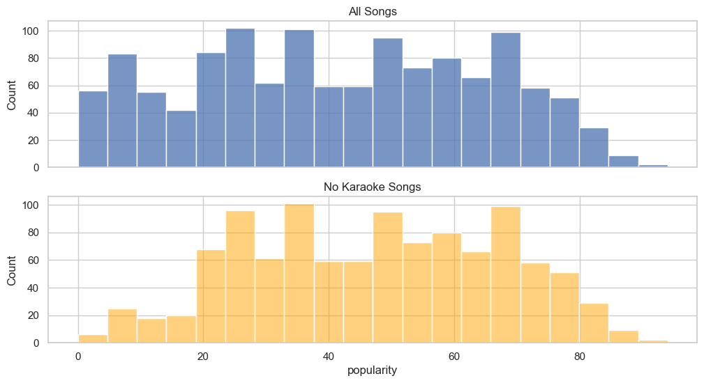

```python
sns.color_palette('flare')
f, (ax1, ax2) = plt.subplots(2, 1, figsize=(12, 6), sharex=True)
sns.histplot(songs['popularity'], ax=ax1, bins=20)
ax1.set_title('All Songs')

sns.histplot(songs_no_karaoke['popularity'], ax=ax2, \
    color='orange', bins=20, alpha=0.5)
ax2.set_title('No Karaoke Songs')
```

#### My Interpretation

From the two distribution, it is obvious that:

- The distribution without karaoke songs is more close to the normal distribution, while the distribution of all songs has more low-popilarity songs
- It may because these the albums containing "karaoke" are limited to the karaoke and the popularity is therefor lower
- Songs with popularity > 25 share almost the same pattern

### IMPORTANT NOTE: the remainder of the questions are based on the songs that are NOT from karaoke albums.

Q2: Report the average track duration for each album. You answer should be in mm:ss (minutes:seconds) format rather than the milliseconds that are reported in the original dataset.

```python
album_average = songs_no_karaoke.groupby('album')['duration_ms'].mean().\
    reset_index()
album_average['avg_duration'] = \
    pd.to_datetime(album_average['duration_ms'], unit='ms').\
        dt.strftime('%M:%S')
album_average
```

|  | album | duration_ms | avg_duration |
| --- | --- | --- | --- |
| 0 | 1989 | 225220.307692 | 03:45 |
| 1 | 1989 (Big Machine Radio Release Special) | 157213.307692 | 02:37 |
| 2 | 1989 (Deluxe Edition) | 221456.617647 | 03:41 |
| 3 | 1989 (Deluxe) | 217139.368421 | 03:37 |
| 4 | Fearless | 240446.841270 | 04:00 |
| 5 | Fearless (Big Machine Radio Release Special) | 153937.615385 | 02:33 |
| 6 | Fearless (International Version) | 240495.500000 | 04:00 |
| 7 | Fearless (Platinum Edition) | 250874.105263 | 04:10 |
| 8 | Fearless (Taylor's Version) | 245865.000000 | 04:05 |
| 9 | Fearless Platinum Edition | 250874.789474 | 04:10 |
| 10 | Live From Clear Channel Stripped 2008 | 209469.375000 | 03:29 |
| 11 | Lover | 206187.833333 | 03:26 |
| 12 | Midnights | 203718.307692 | 03:23 |
| 13 | Midnights (3am Edition) | 208463.200000 | 03:28 |
| 14 | Red | 244802.843750 | 04:04 |
| 15 | Red (Big Machine Radio Release Special) | 158172.593750 | 02:38 |
| 16 | Red (Deluxe Edition) | 246671.250000 | 04:06 |
| 17 | Red (Taylor's Version) | 261327.666667 | 04:21 |
| 18 | Speak Now | 287283.928571 | 04:47 |
| 19 | Speak Now (Big Machine Radio Release Special) | 179268.464286 | 02:59 |
| 20 | Speak Now (Deluxe Edition) | 275520.350000 | 04:35 |
| 21 | Speak Now (Deluxe Package) | 275969.500000 | 04:35 |
| 22 | Speak Now (Japanese Version) | 286343.875000 | 04:46 |
| 23 | Speak Now (US Version) | 287357.785714 | 04:47 |
| 24 | Speak Now World Tour Live | 297121.187500 | 04:57 |
| 25 | Taylor Swift | 213971.133333 | 03:33 |
| 26 | Taylor Swift (Big Machine Radio Release Special) | 146541.966667 | 02:26 |
| 27 | evermore | 243014.000000 | 04:03 |
| 28 | evermore (deluxe version) | 243816.235294 | 04:03 |
| 29 | folklore | 238536.687500 | 03:58 |
| 30 | folklore (deluxe version) | 236964.147059 | 03:56 |
| 31 | folklore: the long pond studio sessions (from ... | 237682.985294 | 03:57 |
| 32 | reputation | 223020.000000 | 03:43 |
| 33 | reputation (Big Machine Radio Release Special) | 164270.354839 | 02:44 |
| 34 | reputation Stadium Tour Surprise Song Playlist | 242956.260870 | 04:02 |

```python
album_average.sort_values(by='avg_duration', ascending=False).\
    reset_index(drop=True).head(20)
```

|  | album | duration_ms | avg_duration |
| --- | --- | --- | --- |
| 0 | Speak Now World Tour Live | 297121.187500 | 04:57 |
| 1 | Speak Now (US Version) | 287357.785714 | 04:47 |
| 2 | Speak Now | 287283.928571 | 04:47 |
| 3 | Speak Now (Japanese Version) | 286343.875000 | 04:46 |
| 4 | Speak Now (Deluxe Package) | 275969.500000 | 04:35 |
| 5 | Speak Now (Deluxe Edition) | 275520.350000 | 04:35 |
| 6 | Red (Taylor's Version) | 261327.666667 | 04:21 |
| 7 | Fearless (Platinum Edition) | 250874.105263 | 04:10 |
| 8 | Fearless Platinum Edition | 250874.789474 | 04:10 |
| 9 | Red (Deluxe Edition) | 246671.250000 | 04:06 |
| 10 | Fearless (Taylor's Version) | 245865.000000 | 04:05 |
| 11 | Red | 244802.843750 | 04:04 |
| 12 | evermore (deluxe version) | 243816.235294 | 04:03 |
| 13 | evermore | 243014.000000 | 04:03 |
| 14 | reputation Stadium Tour Surprise Song Playlist | 242956.260870 | 04:02 |
| 15 | Fearless | 240446.841270 | 04:00 |
| 16 | Fearless (International Version) | 240495.500000 | 04:00 |
| 17 | folklore | 238536.687500 | 03:58 |
| 18 | folklore: the long pond studio sessions (from ... | 237682.985294 | 03:57 |
| 19 | folklore (deluxe version) | 236964.147059 | 03:56 |

#### My Interpretation

- The Top album with the highest average duration time is Speak Now World Tour Live, Speak Now (US Version), Speak Now, Speak Now (Japanese Version) and Speak Now (Deluxe Package)
- There are 17 albums whose duration time are above 4 minutes

Q3: Show a heatmap of the correlations between the features. Use a diverging colormap with white in the middle (i.e. white at a correlation of 0.0).

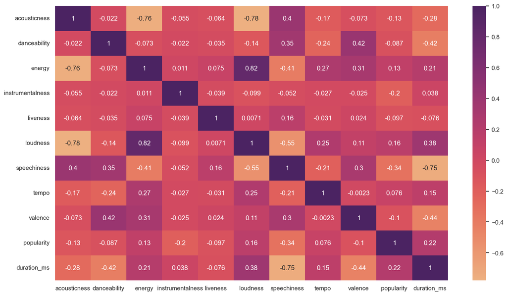

```python
songs_no_karaoke_feature = \
              songs_no_karaoke[['acousticness', 'danceability', 'energy',
             'instrumentalness', 'liveness', 'loudness', 'speechiness',
             'tempo', 'valence', 'popularity',
             'duration_ms']]
plt.figure(figsize=(16, 9))
sns.heatmap(songs_no_karaoke_feature.corr(), cmap='flare', annot=True)
```

#### My Interpretation

The hearmap shows the ralationship between the features.

- Loudness enjoys the highest positive correlation with energy
- Three bottom negative correlations: energy & acousticness, loudness & acousticness, speechiness & duration time

Q4: List the top 5 correlations between the features of the songs.

```python
t = songs_no_karaoke_feature.corr().stack().reset_index()
t.columns = ['var1', 'var2', 'corr']
t = t[t['var1'] != t['var2']]
t = t.sort_values('corr', ascending=False, key=abs)
t = t.reset_index(drop=True)
t = t.iloc[::2]
t.head(5)
```

|  | var1 | var2 | corr |
| --- | --- | --- | --- |
| 0 | loudness | energy | 0.817729 |
| 2 | loudness | acousticness | -0.777471 |
| 4 | acousticness | energy | -0.756873 |
| 6 | duration_ms | speechiness | -0.747227 |
| 8 | speechiness | loudness | -0.549766 |

#### My Interpretation

The top 5 correlations are loudness & energy, loudness & acousticness, acousticness & energy, duration_ms & speechiness, speechiness & loudness.

Q5: Does the position of the track on the album (i.e. track number) have an effect on the popularity of the song? Use both visual and statistical evidence to support your answer.

```python
import statsmodels.api as sm
import statsmodels.formula.api as smf
```

```python
model = smf.ols("track_number ~ popularity", data=songs_no_karaoke).fit()
model.summary()
```

OLS Regression Results

| Dep. Variable: | track_number | R-squared: | 0.030 |
| --- | --- | --- | --- |
| Model: | OLS | Adj. R-squared: | 0.029 |
| Method: | Least Squares | F-statistic: | 33.51 |
| Date: | Mon, 09 Oct 2023 | Prob (F-statistic): | 9.28e-09 |
| Time: | 01:34:55 | Log-Likelihood: | -3681.8 |
| No. Observations: | 1075 | AIC: | 7368. |
| Df Residuals: | 1073 | BIC: | 7378. |
| Df Model: | 1 |  |  |
| Covariance Type: | nonrobust |  |  |

|  | coef | std err | t | P>\|t\| | [0.025 | 0.975] |
| --- | --- | --- | --- | --- | --- | --- |
| Intercept | 14.1068 | 0.581 | 24.279 | 0.000 | 12.967 | 15.247 |
| popularity | -0.0655 | 0.011 | -5.789 | 0.000 | -0.088 | -0.043 |

| Omnibus: | 194.474 | Durbin-Watson: | 0.351 |
| --- | --- | --- | --- |
| Prob(Omnibus): | 0.000 | Jarque-Bera (JB): | 358.962 |
| Skew: | 1.089 | Prob(JB): | 1.13e-78 |
| Kurtosis: | 4.809 | Cond. No. | 132. |

Notes:  
[1] Standard Errors assume that the covariance matrix of the errors is correctly specified.

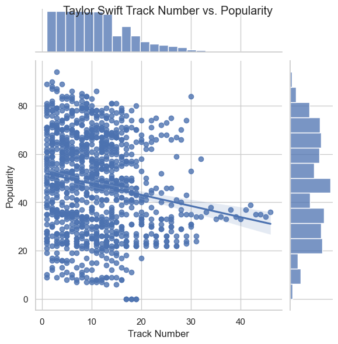

```python
sns.set(style="whitegrid")

g = sns.JointGrid(data=songs_no_karaoke, x="track_number", y="popularity")

sns.regplot(data=songs_no_karaoke, x="track_number", y="popularity", \
    ax=g.ax_joint)
sns.histplot(data=songs_no_karaoke, x="track_number", ax=g.ax_marg_x)
sns.histplot(data=songs_no_karaoke, y="popularity", ax=g.ax_marg_y)

g.set_axis_labels("Track Number", "Popularity")
g.fig.suptitle("Taylor Swift Track Number vs. Popularity")
```

#### My Interpretation

The model explored the relationship between the dependent variable "track_number" and the independent variable "popularity."

- The R-squared value was 0.030, indicating a limited explanation of 3% of the target variable's variation
- The F-statistic was 33.51 with a very low associated p-value (approximately 9.28e-09), signifying strong overall model significance.
- Also from the visual diagram, we can find a regression line

All this suggests that "popularity" has a significant impact on "track_number."

Q6: Are popular songs more danceable? Divide the songs into popular (i.e. those with a popularity rating of 60 or higher) and less popular (i.e. those with a popularity rating of less than 60). Conduct an ANOVA test for the two groups of data based on danceability feature. Are they statistically significant?

```python
songs_no_karaoke.loc[:, 'if_high_pop'] = \
    np.where(songs_no_karaoke['popularity'] >= 60, 1, 0)
songs_no_karaoke['if_high_pop'].value_counts()
```

```
if_high_pop
0    730
1    345
Name: count, dtype: int64
```

```python
model = smf.ols('danceability ~ if_high_pop', data=songs_no_karaoke).fit()
table = sm.stats.anova_lm(model, typ=2)
table
```

|  | sum_sq | df | F | PR(>F) |
| --- | --- | --- | --- | --- |
| if_high_pop | 0.055988 | 1.0 | 4.435697 | 0.035427 |
| Residual | 13.543677 | 1073.0 | NaN | NaN |

Q7: Create a regression model with "popularity" as the dependent variable and "liveness" as the predictor variable. Report the following:

1. Coefficient of determination (i.e. $r^2$)
2. Whether the regression is statistically significant
3. An estimate for the value of "popularity" when the value of "liveness" is 0.22.

```python
model = smf.ols('popularity ~ liveness', data=songs_no_karaoke).fit()
model.summary()
```

OLS Regression Results

| Dep. Variable: | popularity | R-squared: | 0.009 |
| --- | --- | --- | --- |
| Model: | OLS | Adj. R-squared: | 0.008 |
| Method: | Least Squares | F-statistic: | 10.12 |
| Date: | Mon, 09 Oct 2023 | Prob (F-statistic): | 0.00150 |
| Time: | 01:34:57 | Log-Likelihood: | -4743.8 |
| No. Observations: | 1075 | AIC: | 9492. |
| Df Residuals: | 1073 | BIC: | 9502. |
| Df Model: | 1 |  |  |
| Covariance Type: | nonrobust |  |  |

|  | coef | std err | t | P>\|t\| | [0.025 | 0.975] |
| --- | --- | --- | --- | --- | --- | --- |
| Intercept | 49.8667 | 1.017 | 49.048 | 0.000 | 47.872 | 51.862 |
| liveness | -16.1986 | 5.091 | -3.182 | 0.002 | -26.188 | -6.210 |

| Omnibus: | 183.152 | Durbin-Watson: | 0.400 |
| --- | --- | --- | --- |
| Prob(Omnibus): | 0.000 | Jarque-Bera (JB): | 41.318 |
| Skew: | -0.056 | Prob(JB): | 1.07e-09 |
| Kurtosis: | 2.046 | Cond. No. | 8.57 |

Notes:  
[1] Standard Errors assume that the covariance matrix of the errors is correctly specified.

#### My Explanation

Q8: Due to intellectual property conflicts, Taylor Swift re-recorded some of her earlier albums, including `Fearless` and `Red`. We assume that re-recording her early albums will allow Taylor Swift to reclaim her artistry control, revisit the songs and make any changes she wants. Therefore, we want to see whether the new songs are more loved by the audiences by looking at the popularity score.

- The re-recorded ones have `(Taylor’s version)` at the end of the album name.

a) Create a visualization that shows the distribution of popularity scores of original vs. re-recorded songs. There are multiple visualizations that would be appropriate here. You can choose any of them. At a minimum, you should create one visualization. Creating additional ones can earn you additional points.

b) Is there a statistically significant difference between the popularity scores of the original and re-recorded songs? If so, which one is more popular? How much more popular is it, on average?

```python
re_recorded = songs_no_karaoke\
    [songs_no_karaoke.album.str.contains(r"(Taylor's Version)")]
re_recorded.album.unique()
```

```
array(["Red (Taylor's Version)", "Fearless (Taylor's Version)"],
      dtype=object)
```

```python
original = songs_no_karaoke\
    [(songs_no_karaoke.album == "Red") \
        | (songs_no_karaoke.album == "Fearless")]
original.album.unique()
```

```
array(['Red', 'Fearless'], dtype=object)
```

```python
songs_no_karaoke.loc[songs_no_karaoke.album.isin(re_recorded.album), 're_recorded'] \
    = 're_recorded'
songs_no_karaoke.loc[songs_no_karaoke.album.isin(original.album), 're_recorded'] \
    = 'original'
```

a)

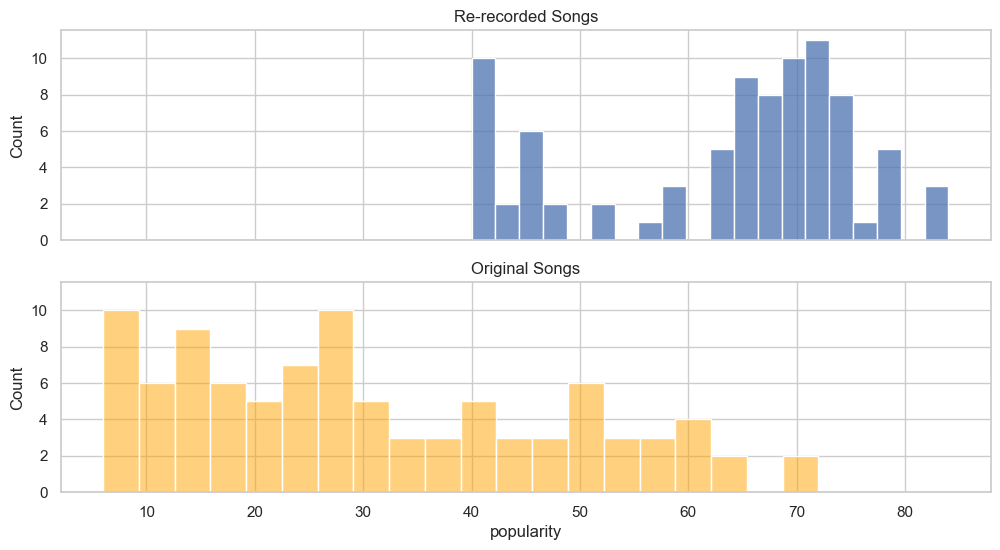

```python
sns.color_palette('flare')
f, (ax1, ax2) = plt.subplots(2, 1, figsize=(12, 6), sharex=True, sharey=True)
sns.histplot(re_recorded['popularity'], ax=ax1, bins=20)
ax1.set_title('Re-recorded Songs')

sns.histplot(original['popularity'], ax=ax2, \
    color='orange', bins=20, alpha=0.5)
ax2.set_title('Original Songs')
```

```python
songs_no_karaoke_drop = \
    songs_no_karaoke.dropna(subset=['re_recorded'])
songs_no_karaoke_drop['album'].value_counts()
```

```
album
Fearless                       63
Red (Taylor's Version)         60
Red                            32
Fearless (Taylor's Version)    26
Name: count, dtype: int64
```

```python
def multiplePlots(series):

    fig, axs = plt.subplots(2, 2)
    plt.tight_layout(pad=0.4, w_pad=4, h_pad=1.0)

    # Histogram
    sns.histplot(series, ax=axs[0, 0], bins=20)

    # Lag plot
    lag = series.copy()
    lag = np.array(lag[:-1])
    current = series[1:]
    ax = sns.regplot(x=current, y=lag, fit_reg=False, ax=axs[0, 1])
    ax.set_ylabel("y_i-1")
    ax.set_xlabel("y_i")

    # QQ plot (updated 2023.08.18.1.CT to match usual QQ plot -- axes flipped)
    qntls, xr = stats.probplot(series, fit=False)
    sns.regplot(y=xr, x=qntls, ax=axs[1, 0])

    # Run sequence
    ax = sns.regplot(x=np.arange(len(series)), y=series, ax=axs[1, 1])
    ax.set_ylabel("val")
    ax.set_xlabel("i")
```

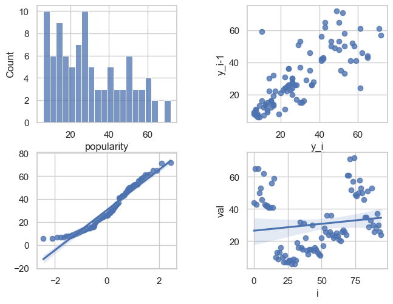

```python
ax1 = multiplePlots(original['popularity'])
```

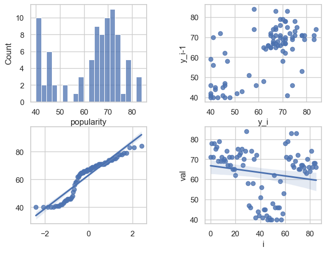

```python
multiplePlots(re_recorded['popularity'])
```

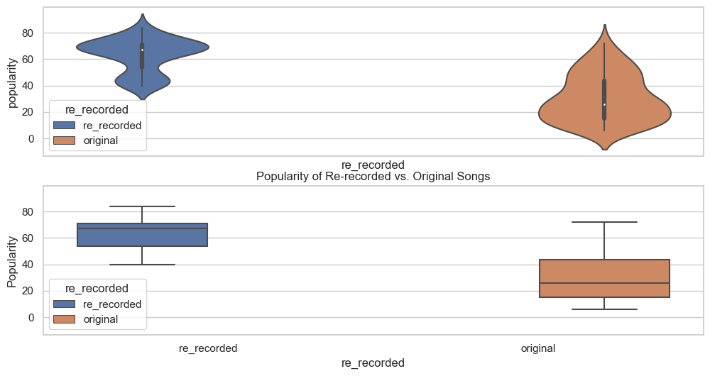

```python
f, (ax1, ax2) = plt.subplots(2, 1, figsize=(12, 6), sharex=True, sharey=True)
sns.violinplot(data=songs_no_karaoke_drop, \
    x='re_recorded', y='popularity', hue="re_recorded", ax=ax1)

sns.boxplot(data=songs_no_karaoke_drop, \
    x='re_recorded', y='popularity', hue="re_recorded", ax=ax2)

plt.ylabel('Popularity')
plt.title('Popularity of Re-recorded vs. Original Songs')
```

Now looking into further. Exploring the reason behind.

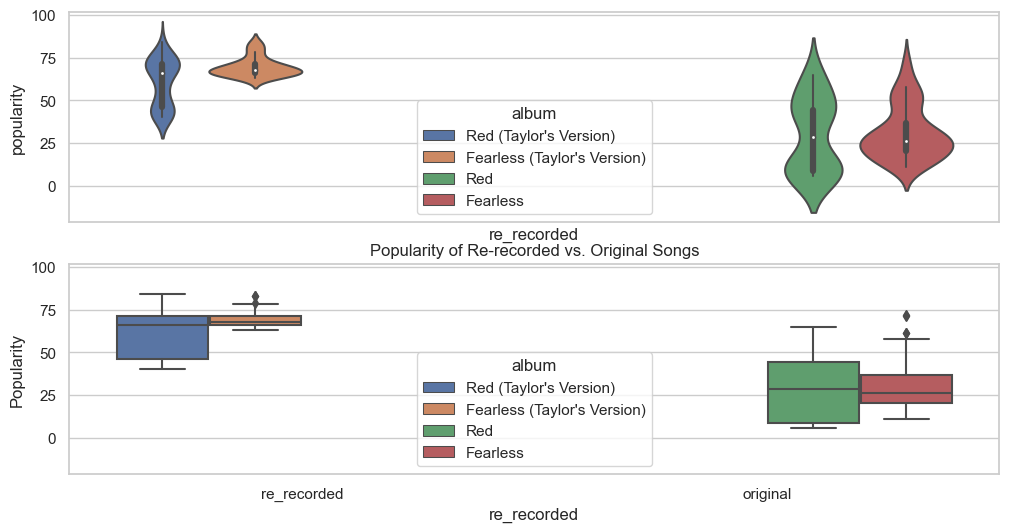

```python
f, (ax1, ax2) = plt.subplots(2, 1, figsize=(12, 6), sharex=True, sharey=True)
sns.violinplot(data=songs_no_karaoke_drop, \
    x='re_recorded', y='popularity', hue='album', ax=ax1)

sns.boxplot(data=songs_no_karaoke_drop, \
    x='re_recorded', y='popularity', hue='album', ax=ax2)

plt.ylabel('Popularity')
plt.title('Popularity of Re-recorded vs. Original Songs')
```

```python
original.sort_values(by='popularity', ascending=False)\
    [['name', 'popularity']].head(5)
```

|  | name | popularity |
| --- | --- | --- |
| 1058 | You Belong With Me | 72 |
| 1055 | Love Story | 71 |
| 689 | Red | 65 |
| 691 | I Knew You Were Trouble. | 65 |
| 695 | We Are Never Ever Getting Back Together | 62 |

#### My Explanation

- From the histogram, the violin and the box plot, it is obvious that the re-recorded songs all enjoy a high popularity while the orginal ones are less popular and is right-screwed
- For re-recorded ones, there is a relatively strong deviation when the popularity is between 45 and 65. It may indicated that there is actually a "cut-edge" or inconsistency across songs, which is worth looking into

Therefore, I generated two more plots and split out the exact album's names, to explore the reason behind.

- It is surprising to find that the "cut-edge" or inconsistency comes from the difference in popularity between the two re-recorded albums. Obviously, "Fearless" gains higher popularity with no low-popularity songs while "Red" has more low-popularity songs.
- But the same thing was less obvious in the orignal albums because both of them are more normal compare to the re-recorded ones.

b)

```python
ttest_ind(re_recorded['popularity'], original['popularity'])
```

```
TtestResult(statistic=14.17027996988049, pvalue=4.695609351927961e-31, df=179.0)
```

#### My Explanation

The statistic (approximately 14.17) indicates a significant difference between group means. The extremely low p-value (about 4.7e-31) suggests strong evidence against the null hypothesis. The degrees of freedom (df) is 179. In summary, this t-test result signifies a substantial difference between groups, supported by a high statistic and very low p-value, indicating rejection of the null hypothesis.

BONUS, worth up to 2 points: How would you determine whether [Taylor Swift has had an effect on the popularity of football](https://duckduckgo.com/?q=taylor+swift+football&atb=v314-1&ia=web)? What data would you need? What analysis would you perform? What would you expect the results to be?

Research on this topic may need the combination of both information retrieval and data mining.

1. Data Preparation:

Information Retrieval: Gather information related to Taylor Swift's activities in relation to football, such as news articles, social media mentions, interviews, and public appearances. This information retrieval step involves searching for and collecting relevant textual data.

2. Data Mining:

Text Data Processing: Process the retrieved textual data to extract relevant features. This may also include sentiment analysis.

Correlation Analysis: Statistical analysis to assess the relationship between Taylor Swift's activities and football popularity metrics. Use correlation coefficients or regression analysis.

Time-Series Analysis: Examine temporal patterns by analyzing time-series data of both Taylor Swift's activities and football popularity metrics. Explore whether spikes in her activities coincide with changes in football popularity.

Hypothesis Testing: Conduct hypothesis tests to determine the statistical significance of any observed correlations or patterns. For example, test whether Taylor Swift's presence significantly affects football viewership or engagement.

3. Expected Results:

Positive Effect: If analysis reveals a positive correlation, it may imply that her involvement has a positive impact on the sport.

No significant correlation: It suggests that Taylor Swift's activities and football popularity are unrelated.

Negative Effect: Indicate her activities are associated with a decrease in football popularity

### Submit your completed assignment in both IPYNB and HTML formats.